# Chromatin and Hi-C signatures of enhancer - target pairs (Figure 3f,g)

Schraivogel, Gschwind et al.

January 19, 2020

This vignette reproduces the analysis in Figure 3f,g of Schraivogel, Gschwind, et al.

## Data

This analysis is based on the ehancer screen experiments. Candidate enhancers within 2 genomic regions on chromosome 8 and 11 were each targeted with 4 gRNA. TAP-seq was used to measure the expression levels of all genes within these regions.

Differential gene expression analyses (MAST) was used to identify target genes of perturbed enhancers: Genes differentially expressed between cells with a given enhancer perturbation versus 1000 randomly selected cells without that perturbation were considered target genes for that enhancer. All performed tests were corrected for multiple testing by calculating the false positive rate (FDR) and only enhancer - target pairs (ETPs) with an FDR below 0.05 were retained.

The code for differential gene expression analyses can be found in *“scripts/analyses/differential_expression.R”* and *“scripts/analyses/process_de_results.R”*. Different models were explored and more analyses can be found in *“vignettes/Figure2.Rmd”*.

Here the chromatin signatures and Hi-C interaction frequencies of inferred ETPs are investigated, which are shown in Figure 3f,g in the manuscript. Chromatin data are downloaded from [ENCODE](https://www.encodeproject.org/) and Hi-C data from [Rao et al., 2014](https://www.sciencedirect.com/science/article/pii/S0092867414014974?via%3Dihub). Chromatin and Hi-C data can be downloaded by running following snakemake rules from within the parent directory:

```bash
snakemake download_chromatin_data download_hic_data
```

All enhancer screen analyses can be performed by running:

```bash
snakemake --use-conda enhancer_screen
```

To reproduce the analyses in this vignette the differential expression results need to be imported:

```r
suppressPackageStartupMessages(library(tidyverse))

# download differential gene expression output. if the snakemake workflow was executed, this file
# can be found under 'data/diff_expr_screen_nGenesCovar.csv'
de_output <- read.csv(url("http://steinmetzlab.embl.de/TAPdata/diff_expr_screen_nGenesCovar.csv"),
                      stringsAsFactors = FALSE)

# change sample id to a more meaningful name and add a variable for significant ETPs
de_output <- de_output %>%
  mutate(sample = paste0("chr", sub("iScreen1", "", sample))) %>%
  mutate(significant = if_else(pval_adj_allTests < 0.05, true = "sig", false = "non_sig"))
```

## Chromatin activity of enhancers (Figure 3f)

Chromatin assays from ENCODE were downloaded and the fold change over control signal is calculated for every assessed enhancer. Significant enhancers are then compared to non-significant enhancers with a similar distance to TSS distribution to identify enrichment of chromatin marks at functionally verified enhancers. More chromatin analyses can be found in *“scripts/analyses/chromatin_analyses_screen.Rmd”*.

```r
suppressPackageStartupMessages(library(ggpubr))
suppressPackageStartupMessages(library(here))
suppressPackageStartupMessages(library(GenomicRanges))
suppressPackageStartupMessages(library(rtracklayer))
```

### Chromatin activity at enhancers

The fold change over control signal of different enhancer and transcription relevant chromatin marks is computed for the enhancer of every tested enhancer - target gene pair.

```r
# extract cis enhancer - gene pairs, remove significant pairs that increase gene expression
cis_enh_perts <- de_output %>%
  filter(enh_type == "cis", abs(dist_to_tss) >= 1000) %>%
  filter(!(significant == "sig" & manual_lfc > 0))

# only retain hits within the same target region (discard out of region control enhancers) and add
# "chr" to enhancer chromosome for use with ENCODE data
cis_enh_perts <- cis_enh_perts %>%
  filter(enh_chr == sub("chr", "", sample)) %>%
  mutate(enh_chr = paste0("chr", enh_chr),
         gene_chr = paste0("chr", gene_chr))

# get enhancer coordinates and convert to GRanges object
enh_coords <- cis_enh_perts %>%
  select(enh_chr, enh_start, enh_end, perturbation) %>%
  distinct() %>%
  makeGRangesFromDataFrame(keep.extra.columns = TRUE) %>%
  `names<-`(.$perturbation)  # set names to perturbation id

# bigWig files containing encode chromatin data
chrom_assays <- c("H3K27ac",  "H3K4me1",  "H3K4me3", "H3K27me3", "POLR2A")
chrom_files  <- here("data", "k562_chromatin_data",
                     paste0(chrom_assays, "_encode_chipseq_fcOverCtrl.bigWig"))
names(chrom_files) <- chrom_assays

# load chromatin data for targeted genomic regions
chrom_data <- lapply(chrom_files, FUN = import, which = range(enh_coords), format = "bigWig")

# function to calculate average assay signal per enhancer
avg_assay_signal <- function(assay, enh_coords) {
  overlaps <- findOverlaps(enh_coords, assay)
  overlaps <- split(overlaps, from(overlaps))
  names(overlaps) <- names(enh_coords[as.numeric(names(overlaps))])
  sapply(overlaps, function(x) {
    sum(mcols(assay[to(x)])$score * width(assay[to(x)])) / sum(width(assay[to(x)]))
  })
}

# calculate average chromatin signal at enhancers
enh_chrom_signal <- chrom_data %>%
  sapply(FUN = avg_assay_signal, enh_coords = enh_coords) %>%
  as.data.frame() %>%
  rownames_to_column(var = "perturbation")

# transform to data.frame and merge with cis enhancer - gene pairs
cis_enh_perts <- cis_enh_perts %>%
  select(sample, perturbation, enh_chr, gene, pvalue, prop_grna_hits, dist_to_tss, significant) %>%
  left_join(enh_chrom_signal, by = "perturbation")
```

### Normalize for distance to TSS

Enhancers significantly associated with gene expression changes tend to be located in closer proximity to the target genes TSS than any enhancer to any gene on average. However, every enhancer has a large spectrum of distances to TSS to all tested genes within the region. To compare singificant to non-significant enhancers an negative control sample is generated by randomly sampling. For each significant enhancer - gene pair, three non-significant enhancer - gene pairs are drawn, whose enhancers have at least one gene with similar distance to TSS as the significant enhancer - gene pair. To ensure an independent control sample, pairs involing drawn enhancers are removed from subsequent sampling. This ensures that no enhancer appears more than once in the control sample. The number of drawn controls per significant pair is set to 3, because with higher numbers there are simply not enough non-significant enhancer - gene pairs available for sampling without duplicating enhancers.

```r
# function to randomly draw n non-significant pairs for a significant association. any enhancers
# from drawn non-significant pairs are excluded from subsequent draws
draw_control_pairs <- function(sig, non_sig, n = 3) {

  # get distance to tss bins for which a control pair needs to be drawn (repeat n times)
  bins <- select(sig, enh_chr, dTSS_bin)
  bins <- bins[rep(seq_len(nrow(bins)), each = n), ]

  # iteratively select a random negative control for each bin and remove any pairs involving that
  # enhancer from pool of non-significant pairs for any subsequenct draws
  random_ctrls <- data.frame()
  for (i in seq_len(nrow(bins))) {

    # get pairs on same chromosome and same distance to TSS bin
    nonSig_bin <- filter(non_sig, enh_chr == bins[i, "enh_chr"],
                         dTSS_bin == bins[i, "dTSS_bin"])

    # randomly draw a control pair (if possible)
    if (nrow(nonSig_bin)) {

      ctrl <- sample_n(nonSig_bin, size = 1)
      random_ctrls <- rbind(random_ctrls, ctrl)

      # remove any pairs involving that enhancer from non_sig
      non_sig <- filter(non_sig, perturbation != ctrl$perturbation)

    }else{
      warning("Not enough unique enhancers to draw control!\n", call. = FALSE)
    }
  }

  return(random_ctrls)

}
```

```r
# create distance to TSS bins
dtss_range <- range(cis_enh_perts$dist_to_tss)
bins <- seq(from = dtss_range[1], to = dtss_range[2], by = 1e4)

# bin distance to tss
cis_enh_perts <- cis_enh_perts %>%
  mutate(dTSS_bin = cut(dist_to_tss, bins))

# extract significant enhancer - gene associations
sig_pairs <- filter(cis_enh_perts, significant == "sig")

# get other tested enhancer - gene pairs but whose enhancers appear only in non-sigificant tests
nonSig_pairs <- cis_enh_perts %>%
  filter(significant == "non_sig", !perturbation %in% sig_pairs$perturbation,
         perturbation != "GATA1")  # no GATA1, because it's the only on chrX

# randomly draw 3 control pairs for each significant enhancer - gene association
set.seed(20190617)
nonSig_ctrls <- draw_control_pairs(sig_pairs, non_sig = nonSig_pairs, n = 3)
# combine significant and control pairs
all_pairs <- bind_rows(sig_pairs, nonSig_ctrls)
```

### Chromatin activity vs confidence levels

Enhancer - target pairs are classified as strong or weak ETPs based on the proportion of individual gRNAs confirming a given ETP. Chromatin activity of chromatin assays linked to active enhancers at are then compared between the confidence levels and non-significant controls.

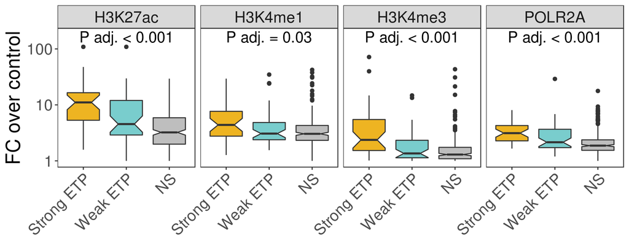

```r
# add label for confidence level based on prop gRNA hits
all_pairs_conf <- all_pairs %>%
  filter(!is.na(prop_grna_hits)) %>%
  mutate(conf = if_else(significant == "sig" & prop_grna_hits >= 0.5,
                        true = "High confidence", false = "Non significant"),
         conf = if_else(significant == "sig" & prop_grna_hits < 0.5,
                        true = "Low confidence", false = conf))

# convert to long format for plot
all_pairs_conf <- all_pairs_conf %>%
  gather(key = "assay", value = "fc_over_ctrl", -c(1:8, dTSS_bin, conf))

# perform kruskal-wallis test (non-parametric one-way anova) per assay and reformat adjusted p-value
kw_tests <- compare_means(formula = fc_over_ctrl ~ conf, method = "kruskal.test",
                          data = all_pairs_conf, group.by = "assay") %>%
  mutate(p.adj.plot = if_else(p.adj < 0.001, true = "< 0.001",
                              false = paste("=", round(p.adj, digits = 2)))) %>%
  mutate(group1 = "High confidence", group2 = "Low confidence")  # add fake groups for text in plots

# plot chromatin signal for high-, low-confidence and non significant enhancer - gene pairs
all_pairs_conf %>%
  filter(assay != "H3K27me3") %>%
  ggplot(., aes(x = conf, y = fc_over_ctrl + 1, fill = conf)) +
  facet_wrap(~assay, ncol = 4) +
  geom_boxplot(notch = TRUE) +
  stat_pvalue_manual(data = filter(kw_tests, assay != "H3K27me3"), y.position = 130, size = 5.5,
                     label = "P adj. {p.adj.plot}", remove.bracket = TRUE, inherit.aes = FALSE) +
  labs(y = "FC over control") +
  scale_x_discrete(labels = c("Strong ETP", "Weak ETP", "NS")) +
  scale_fill_manual(values = c("High confidence" = "goldenrod2",
                               "Low confidence" = "darkslategray3", "Non significant" = "gray")) +
  scale_y_log10(limits = c(NA, 180)) +
  theme_bw() +
  theme(axis.title.x = element_blank(), legend.position = "none", text = element_text(size = 20),
        panel.grid = element_blank(), axis.text.x = element_text(angle = 45, hjust = 1))
```

H3K27me3 is associated with inactive chromatin and is not enriched at the discovered enhancers:

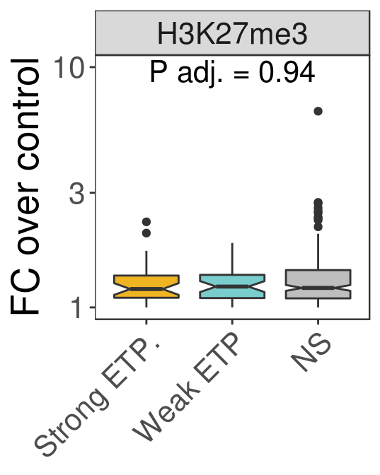

```r
# plot H3K27me3 vs confidence levels
all_pairs_conf %>%
  filter(assay == "H3K27me3") %>%
  ggplot(., aes(x = conf, y = fc_over_ctrl + 1, fill = conf)) +
  facet_wrap(~assay) +
  geom_boxplot(notch = TRUE) +
  stat_pvalue_manual(data = filter(kw_tests, assay == "H3K27me3"), y.position = 8.7, size = 5.5,
                     label = "P adj. {p.adj.plot}", remove.bracket = TRUE, inherit.aes = FALSE) +
  labs(y = "FC over control") +
  scale_x_discrete(labels = c("Strong ETP.", "Weak ETP", "NS")) +
  scale_fill_manual(values = c("High confidence" = "goldenrod2",
                               "Low confidence" = "darkslategray3", "Non significant" = "gray")) +
  scale_y_log10(limits = c(NA, 10)) +
  theme_bw() +
  theme(axis.title.x = element_blank(), legend.position = "none", text = element_text(size = 20),
        panel.grid = element_blank(), axis.text.x = element_text(angle = 45, hjust = 1))
```

## Hi-C interaction frequencies of ETPs (Figure 3g)

```r
suppressPackageStartupMessages(library(ggpubr))
suppressPackageStartupMessages(library(here))
suppressPackageStartupMessages(library(HiTC))
suppressPackageStartupMessages(library(Matrix))
suppressPackageStartupMessages(library(rtracklayer))
suppressPackageStartupMessages(library(tools))
```

### Liftover ETPs

Hi-C data was aligned to human hg19, so enhancer and gene coordinates have to be lifted over from hg38 to hg19.

```r
# extract cis-interactions, remove validation controls on other chromosomes than the samples'
# target region and remove significant hits that increase gene expression
cis_enh_perts <- de_output %>%
  filter(enh_type == "cis", abs(dist_to_tss) >= 1000) %>%
  mutate(enh_chr = paste0("chr", enh_chr), gene_chr = paste0("chr", gene_chr)) %>%
  filter(sample == enh_chr) %>%
  filter(!(significant == "sig" & manual_lfc > 0))

# download chain file for hg38 to hg19 liftover
chain_url <- "http://hgdownload.cse.ucsc.edu/goldenPath/hg38/liftOver/hg38ToHg19.over.chain.gz"
chain_file <- tempfile("hg38ToHg19", fileext = ".gz")
download.file(chain_url, chain_file)
system(paste("gunzip", chain_file))

# import chain file
hg38_to_hg19_chain <- import.chain(file_path_sans_ext(chain_file))

# extract hg38 enhancer coordinates
enh_coords_hg38 <- cis_enh_perts %>%
  select(perturbation, enh_chr, enh_start, enh_end) %>%
  distinct() %>%
  makeGRangesFromDataFrame(keep.extra.columns = TRUE, seqnames.field = "enh_chr",
                           start.field = "enh_start", end.field = "enh_end")

# liftover enhancers from hg38 to hg19 and convert to data.frame
enh_coords_hg19 <- enh_coords_hg38 %>%
  liftOver(chain = hg38_to_hg19_chain) %>%
  unlist() %>%
  as.data.frame() %>%
  select(seqnames, start, end, perturbation) %>%
  dplyr::rename(enh_chr = seqnames, enh_start = start, enh_end = end)

# replace tested enhancer - gene pairs hg38 enhancer coordinates with hg19 coordinates
cis_enh_perts <- cis_enh_perts %>%
  select(-c(enh_chr, enh_start, enh_end)) %>%
  left_join(enh_coords_hg19, by = "perturbation")

# extract gene TSS coordinates
gene_tss_hg38 <- cis_enh_perts %>%
  select(gene, gene_chr, gene_tss, gene_strand) %>%
  distinct() %>%
  makeGRangesFromDataFrame(keep.extra.columns = TRUE, seqnames.field = "gene_chr",
                           start.field = "gene_tss", end.field = "gene_tss",
                           strand.field = "gene_strand")

# liftover tss coordinates to hg19
gene_tss_hg19 <- gene_tss_hg38 %>%
  liftOver(chain = hg38_to_hg19_chain) %>%
  unlist() %>%
  as.data.frame() %>%
  select(seqnames, start, strand, gene) %>%
  dplyr::rename(gene_chr = seqnames, gene_tss = start, gene_strand = strand)

# replace gene tss hg38 coordinates with hg19 coordinates
cis_enh_perts <- cis_enh_perts %>%
  select(-c(gene_chr, gene_tss, gene_strand)) %>%
  left_join(gene_tss_hg19, by = "gene")

# recalculate distance to tss for hg19 coordinates
cis_enh_perts <- cis_enh_perts %>%
  mutate(enh_center = round((enh_start + enh_end) / 2)) %>%
  mutate(dist_to_tss = if_else(gene_strand == "+", true  = enh_center - gene_tss,
                                false = gene_tss - enh_center)) %>%
  select(-enh_center)

# add label for confidence level based on prop gRNA hits
cis_enh_perts <- cis_enh_perts %>%
  filter(!is.na(prop_grna_hits)) %>%
  mutate(conf = case_when(
    significant == "non_sig" ~ "NS",
    significant == "sig" & prop_grna_hits >= 0.5 ~ "Strong",
    significant == "sig" & prop_grna_hits <  0.5 ~ "Weak")
  )
```

### Prepare Hi-C data

Hi-C data for k562 cells from Rao et al. 2014 is imported (5kb resolution). The provided normalization vectors are used to normalize the observed contacts (read counts). Data from the two chromosonal regions on chromosome 8 and 11 is extracted for any further analyses.

```r
# function to import HiC data from Rao et al for one chromosome and create a HTCexp object
import_hic <- function(sparse_cm_file, chromosome, resolution, bins) {

  # load sparse contact matrix file (only observed contacts)
  obs_contacts <- read.table(sparse_cm_file, col.names = c("i", "j", "M_ij"), sep = "\t")

  # get starting coordinates of assessed genomic bins at 5kb resolution
  max_bin <- (bins - 1) * resolution
  bin_starts <- seq(from = 0, to = max_bin, by = resolution)

  # create GRanges object containing all assessed bins for that chromosome
  bin_coords <- GRanges(seqnames = chromosome,
                        ranges = IRanges(start = bin_starts, end = bin_starts + resolution - 1,
                                         names = paste0("bin_", seq_len(length(bin_starts))))
                        )

  # convert starting coordinates of bins in sparse matrix input to bin ids by dividing by the
  # resolution (and add 1 to get correct index)
  obs_contacts_bins <- data.frame(i = round(obs_contacts$i / resolution + 1),
                                  j = round(obs_contacts$j / resolution + 1),
                                  M_ij = obs_contacts$M_ij)

  # create sparse contact matrix from observed contacts
  sparse_cm <- sparseMatrix(i = obs_contacts_bins$i, j = obs_contacts_bins$j,
                            x = obs_contacts_bins$M_ij, symmetric = TRUE, dims = c(bins, bins))

  # create HTCexp object containing data for the given chromosome
  HTCexp(intdata = sparse_cm, xgi = bin_coords, ygi = bin_coords)

}
```

```r
# directory containing downloaded Hi-C data
hic_dir <- "data/k562_chromatin_data/HiC/5kb_resolution_intrachromosomal"

# k562 intrachromosomal sparse matrix files for chromosomes 8 and 11
chr8_scm_file  <- here(hic_dir, "chr8/MAPQG0/chr8_5kb.RAWobserved")
chr11_scm_file <- here(hic_dir, "chr11/MAPQG0/chr11_5kb.RAWobserved")

# import normalization vectors
chr8_KRnorm  <- as.numeric(readLines(here(hic_dir, "chr8/MAPQG0/chr8_5kb.KRnorm")))
chr11_KRnorm <- as.numeric(readLines(here(hic_dir, "chr11/MAPQG0/chr11_5kb.KRnorm")))

# infer number of bins per chromosome based on the normalization vectors
chr8_bins  <- length(chr8_KRnorm)
chr11_bins <- length(chr11_KRnorm)

# import hi-c data for these chromosomes
chr8_hic  <- import_hic(chr8_scm_file,  chromosome = "chr8",  resolution = 5000, bins = chr8_bins)
chr11_hic <- import_hic(chr11_scm_file, chromosome = "chr11", resolution = 5000, bins = chr11_bins)
```

```r
# function to normalize Hi-C data based on provided normalization vectors
normalize_hic <- function(htc_obj, norm_vector) {

  # extract raw observed interaction matrix
  raw_obs <- intdata(htc_obj)

  # create normalization matrix by computing the outer product of the normalization vector
  norm_mat <- outer(norm_vector, norm_vector)

  # multiply observed interactions by normalization matrix and add back to HTC object
  intdata(htc_obj) <- raw_obs / norm_mat
  return(htc_obj)

}

# normalize HiC data
chr8_hic_norm  <- normalize_hic(chr8_hic,  norm_vector = chr8_KRnorm)
chr11_hic_norm <- normalize_hic(chr11_hic, norm_vector = chr11_KRnorm)
```

```r
# infer chromosomal region range
region_coords <- cis_enh_perts %>%
  select(sample, enh_start, enh_end, gene_tss) %>%
  gather(key = "key", value = "coord", -sample) %>%
  group_by(sample) %>%
  summarize(start = min(coord), end = max(coord))

# calculate bin coordinates that contain the entire regions
region_bins <- region_coords %>%
  mutate(start = floor(start / 5000) * 5000,
         end = ceiling(end / 5000) * 5000)

# extract data for assessed regions
chr8_region_hic <- extractRegion(chr8_hic_norm, MARGIN = c(1, 2), chr = "chr8",
                                 from = pull(filter(region_bins, sample == "chr8"), start),
                                 to = pull(filter(region_bins, sample == "chr8"), end))

chr11_region_hic <- extractRegion(chr11_hic_norm, MARGIN = c(1, 2), chr = "chr11",
                                  from = pull(filter(region_bins, sample == "chr11"), start),
                                  to = pull(filter(region_bins, sample == "chr11"), end))
```

### Enhancer - gene pairs versus expected interaction frequency over distance

Loci that are in close proximity have a higher expected interaction frequency than loci further from each other. To take this into account, the expected background interaction frequency is computed by looking at the interaction frequencies of all assessed genomic bins within the genomic regions. The interaction frequency of all bins as a function of the distance between bins is defined as the expected background of interactions.

```r
# function to extract interaction frequency versus distance between genomic bins
intFreq_over_distance <- function(htc_obj, type = "background") {

  # extract interaction matrix and compute distances between bins (in bp)
  ints <- intdata(htc_obj)
  dists <- intervalsDist(htc_obj)

  # get unique interactions (upper triangle of matrix, including diagonal), because matrix is
  # symmetric
  ints_unique <- suppressMessages(ints[upper.tri(ints, diag = TRUE)])
  dists_unique <- suppressMessages(dists[upper.tri(dists, diag = TRUE)])

  # create data.frame containing interaction frequency across all in distances
  int_over_dist <- data.frame(dist = dists_unique, int_freq = ints_unique, type = type,
                              stringsAsFactors = FALSE)

  # sort according to distance
  int_over_dist[order(int_over_dist$dist), ]

}

# compute expected background interaction frequency by calculating the distance between all observed
# genomic bins
chr8_int_over_dist  <- intFreq_over_distance(chr8_region_hic)
chr11_int_over_dist <- intFreq_over_distance(chr11_region_hic)

# combine into one data.frame and remove any NaN values, which were introduced because the
# normalization failed for certain bins
expect_int <- bind_rows(chr8 = chr8_int_over_dist, chr11 = chr11_int_over_dist, .id = "sample") %>%
  filter(!is.nan(int_freq))
```

The interaction frequency of all tested enhancer - gene pair is computed, defined as the interaction frequency of the genomic bins overlapping the enhancer and the target genes TSS.

```r
# function to compute the interaction frequency for enhancer - gene pairs, by finding the hi-c
# genomic bins with overlap with the enhancer and the target gene tss. the interaction frequency of
# the pair is then defined as the interaction frequency of these bins
compute_int_freq <- function(pairs, htc_object) {

  # add pair identifier
  pairs$pair <- seq_len(nrow(pairs))

  # get coordinates of enhancer centers as GRanges object
  enh_coords <- pairs %>%
    mutate(enh_center = round((enh_start + enh_end) / 2)) %>%
    select(enh_chr, enh_center) %>%
    makeGRangesFromDataFrame(., seqnames.field = "enh_chr", start.field = "enh_center",
                             end.field = "enh_center")

  # get gene tss coordinates as GRanges object
  tss_coords <- pairs %>%
    select(gene_chr, gene_tss) %>%
    makeGRangesFromDataFrame(., seqnames.field = "gene_chr", start.field = "gene_tss",
                             end.field = "gene_tss")

  # get bins overlapping for all enhancers and gene tss
  hic_bins <- x_intervals(htc_object)
  enh_bins <- findOverlaps(query = enh_coords, subject = hic_bins)
  tss_bins <- findOverlaps(query = tss_coords, subject = hic_bins)

  # combine into one data.frame
  enh_bins <- data.frame(pair = from(enh_bins), enh_bin = to(enh_bins))
  tss_bins <- data.frame(pair = from(tss_bins), tss_bin = to(tss_bins))
  bins <- full_join(enh_bins, tss_bins, by = "pair")

  # extract distance matrix between bins from htc object
  dists <- intervalsDist(htc_object)

  # calculate distances between bins of enhancer gene pairs
  dist_pairs <- dists[as.matrix(bins[, 2:3])]
  dist_pairs <- data.frame(pair = bins$pair, dist_bins = dist_pairs)

  # extract hi-c interaction matrix from htc object
  intdata <- intdata(htc_object)

  # get interaction frequencies for all bins and add pair id
  int_freq_pairs <- intdata[as.matrix(bins[, 2:3])]
  int_freq_pairs <- data.frame(pair = bins$pair, int_freq = int_freq_pairs)

  # add interaction frequencies and bin distances to pairs to create output
  pairs %>%
    left_join(dist_pairs, by = "pair") %>%
    left_join(int_freq_pairs, by = "pair") %>%
    select(-pair)

}
```

```r
# compute interaction frequencies for all tested enhancer - gene pairs
chr8_pairs <- cis_enh_perts %>%
  filter(enh_chr == "chr8", enh_chr == "chr8") %>%
  compute_int_freq(., htc_object = chr8_region_hic)

chr11_pairs <- cis_enh_perts %>%
  filter(enh_chr == "chr11", enh_chr == "chr11") %>%
  compute_int_freq(., htc_object = chr11_region_hic)

# combine into one data.frame and extract relevant columns
int_freq_pairs <- bind_rows(chr8_pairs, chr11_pairs) %>%
  select(sample, dist_bins, int_freq, significant, conf) %>%
  dplyr::rename(dist = dist_bins, type = significant)

# add to expected background frequencies
int_freqs <- expect_int %>%
  mutate(conf = as.character(NA)) %>%
  bind_rows(int_freq_pairs)
```

The interaction frequencies for all ETPs and background are plotted as a function of the distance on the linear genome:

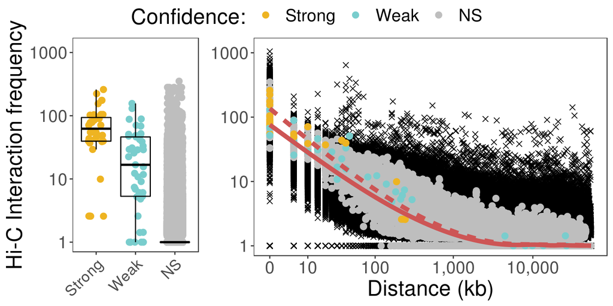

```r
# add an amount equal to bin size to distance for plotting on log10 scale and reformat labels
int_freqs_plot <- int_freqs %>%
  mutate(dist = dist + 5000) %>%
  mutate(sample = sub("c", "C", sample)) %>%
  mutate(conf = fct_relevel(conf, "Strong", "Weak", "NS"))

# plot interaction frequencies across confidence levels and significant vs non-significant
p1 <- ggplot(drop_na(int_freqs_plot), aes(x = conf, y = int_freq + 1, color = conf)) +
  geom_jitter(width = 0.2, size = 2.5) +
  geom_boxplot(color = "black", outlier.shape = NA, fill = NA) +
  labs(y = "Hi-C Interaction frequency", color = "Confidence:") +
  scale_color_manual(values = c("Strong" = "goldenrod2", "Weak" = "darkslategray3",
                                "NS" = "gray")) +
  scale_y_log10(limits = c(NA, 1200), breaks = c(1, 10, 100, 1000)) +
  theme_bw() +
  theme(text = element_text(size = 20), panel.grid = element_blank(),
        axis.title.x = element_blank(),
        axis.text.x = element_text(angle = 45, hjust = 1, size = 14.5))

# plot interaction frequency as a function of distance
x_breaks <- c(0, 10^(4:10))  # breaks to draw on x axis (without added bin distance!)
p2 <- ggplot(int_freqs_plot, aes(x = dist, y = int_freq + 1)) +
  geom_point(data = filter(int_freqs_plot, type == "background"), pch = 4, size = 2,
             color = "black", alpha = 1) +
  geom_point(data = filter(int_freqs_plot, type == "non_sig"), aes(color = conf), alpha = 1,
             size = 2.5) +
  geom_point(data = filter(int_freqs_plot, type == "sig"), aes(color = conf), size = 2.5) +
  geom_smooth(data = filter(int_freqs_plot, type != "sig"), aes(linetype = type),
              color = "indianred3", se = FALSE, lwd = 2) +
  labs(x = "Distance (kb)", y = "Hi-C Interaction frequency", color = "Confidence",
       linetype = "Type") +
  scale_color_manual(values = c("Strong" = "goldenrod2", "Weak" = "darkslategray3",
                                "NS" = "gray")) +
  scale_x_log10(breaks = x_breaks + 5000, labels = scales::comma(x_breaks / 1000)) +
  scale_y_log10(limits = c(NA, 1200), breaks = c(1, 10, 100, 1000)) +
  theme_bw() +
  theme(text = element_text(size = 20), panel.grid = element_blank())

# arrange plots with common legend (props ggpubr!)
ggarrange(p1, p2 + theme(axis.title.y = element_blank()), ncol = 2, nrow = 1, common.legend = TRUE,
          legend = "top", widths = c(1, 2))
```